# Heart Failure Model Validation

Improving Validation Design for Mortality Classification Models

# 1 1. Purpose

This project began as multivariate statistics coursework comparing LDA, QDA, linear and RBF SVM, and an artificial neural network (ANN) for classifying DEATH_EVENT. A portfolio review later found that the reported performances were not directly comparable. LDA and QDA used cross-validation, SVM performance was calculated by predicting the training data, and ANN performance came from one hold-out split.

The updated question is:

> When LDA, QDA, SVM, and ANN models are evaluated under the same resampling design, how do their discrimination performance and error profiles differ?

# 2 2. Data and outcome

```r
raw_data <- read.csv(DATA_PATH)

clinical_variables <- c(
  "age",
  "creatinine_phosphokinase",
  "ejection_fraction",
  "platelets",
  "serum_creatinine",
  "serum_sodium"
)

model_data <- raw_data |>
  dplyr::select(DEATH_EVENT, dplyr::all_of(clinical_variables)) |>
  mutate(
    # caret::twoClassSummary treats the first factor level as the event.
    DEATH_EVENT = factor(
      DEATH_EVENT,
      levels = c(1, 0),
      labels = c("Died", "Survived")
    )
  )

data_summary <- tibble(
  Patients = nrow(model_data),
  Deaths = sum(model_data$DEATH_EVENT == "Died"),
  Survivors = sum(model_data$DEATH_EVENT == "Survived"),
  Missing_values = sum(is.na(model_data))
)

knitr::kable(data_summary)
```

| Patients | Deaths | Survivors | Missing_values |
| --- | --- | --- | --- |
| 299 | 96 | 203 | 0 |

The dataset contains 299 patients, including 96 deaths and 203 survivors. No missing values were found in the analysis variables.

The original dataset includes time, which records follow-up duration. It is not used as an ordinary predictor because doing so would mix post-baseline follow-up information with the classification target and could introduce target-related leakage. This project is neither survival analysis nor prediction of mortality at a fixed time horizon. No Cox model or Kaplan-Meier analysis is added.

# 3 3. Focused exploratory analysis

## 3.1 3.1 Observed group differences

```r
group_summary <- model_data |>
  group_by(DEATH_EVENT) |>
  summarise(
    across(
      all_of(clinical_variables),
      list(mean = mean, median = median),
      .names = "{.col}_{.fn}"
    ),
    .groups = "drop"
  )

knitr::kable(group_summary, digits = 2)
```

| DEATH_EVENT | age_mean | age_median | creatinine_phosphokinase_mean | creatinine_phosphokinase_median | ejection_fraction_mean | ejection_fraction_median | platelets_mean | platelets_median | serum_creatinine_mean | serum_creatinine_median | serum_sodium_mean | serum_sodium_median |
| --- | --- | --- | --- | --- | --- | --- | --- | --- | --- | --- | --- | --- |
| Died | 65.22 | 65 | 670.20 | 259 | 33.47 | 30 | 256381.0 | 258500 | 1.84 | 1.3 | 135.38 | 135.5 |
| Survived | 58.76 | 60 | 540.05 | 245 | 40.27 | 38 | 266657.5 | 263000 | 1.18 | 1.0 | 137.22 | 137.0 |

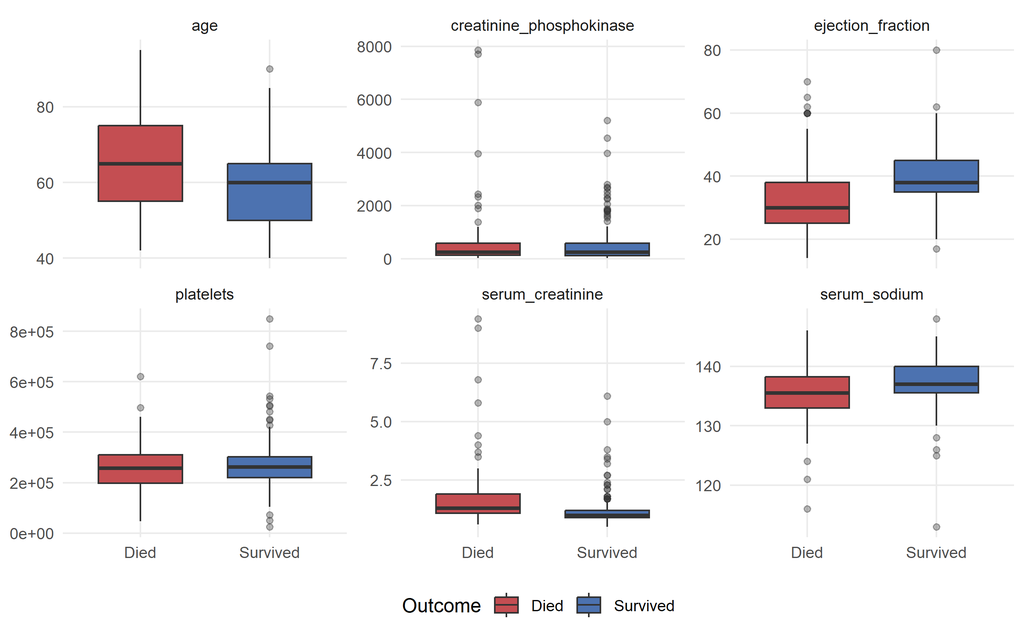

Observed distributions of six clinical variables by outcome group.

```r
boxplot_data <- model_data |>
  pivot_longer(
    cols = all_of(clinical_variables),
    names_to = "Variable",
    values_to = "Value"
  )

group_boxplot <- ggplot(
  boxplot_data,
  aes(x = DEATH_EVENT, y = Value, fill = DEATH_EVENT)
) +
  geom_boxplot(width = 0.65, outlier.alpha = 0.35) +
  facet_wrap(~ Variable, scales = "free_y", ncol = 3) +
  scale_fill_manual(values = c(Died = "#C44E52", Survived = "#4C72B0")) +
  labs(x = NULL, y = NULL, fill = "Outcome") +
  theme_minimal(base_size = 11) +
  theme(legend.position = "bottom", panel.grid.minor = element_blank())

ggsave(
  file.path(FIGURE_PATH, "group_boxplots.png"),
  group_boxplot,
  width = 10,
  height = 6.5,
  dpi = 180
)

group_boxplot
```

The death group was older on average, had lower ejection fraction, higher serum creatinine, and lower serum sodium. These are observed group differences only. This analysis does not estimate adjusted effects, odds ratios, or causal risk factors.

## 3.2 3.2 Correlation and discriminant-analysis assumptions

```r
correlation_matrix <- model_data |>
  dplyr::select(all_of(clinical_variables)) |>
  cor()

knitr::kable(correlation_matrix, digits = 2)
```

|  | age | creatinine_phosphokinase | ejection_fraction | platelets | serum_creatinine | serum_sodium |
| --- | --- | --- | --- | --- | --- | --- |
| age | 1.00 | -0.08 | 0.06 | -0.05 | 0.16 | -0.05 |
| creatinine_phosphokinase | -0.08 | 1.00 | -0.04 | 0.02 | -0.02 | 0.06 |
| ejection_fraction | 0.06 | -0.04 | 1.00 | 0.07 | -0.01 | 0.18 |
| platelets | -0.05 | 0.02 | 0.07 | 1.00 | -0.04 | 0.06 |
| serum_creatinine | 0.16 | -0.02 | -0.01 | -0.04 | 1.00 | -0.19 |
| serum_sodium | -0.05 | 0.06 | 0.18 | 0.06 | -0.19 | 1.00 |

```r
hz_died <- MVN::mvn(
  data = model_data |>
    filter(DEATH_EVENT == "Died") |>
    dplyr::select(all_of(clinical_variables)),
  mvn_test = "hz"
)

hz_survived <- MVN::mvn(
  data = model_data |>
    filter(DEATH_EVENT == "Survived") |>
    dplyr::select(all_of(clinical_variables)),
  mvn_test = "hz"
)

box_m <- biotools::boxM(
  model_data |> dplyr::select(all_of(clinical_variables)),
  grouping = model_data$DEATH_EVENT
)

assumption_results <- tibble(
  Test = c("Henze-Zirkler: Died", "Henze-Zirkler: Survived", "Box's M"),
  P_value = c(
    hz_died$multivariate_normality$p.value,
    hz_survived$multivariate_normality$p.value,
    box_m$p.value
  )
)

knitr::kable(assumption_results, digits = 5)
```

| Test | P_value |
| --- | --- |
| Henze-Zirkler: Died | <0.001 |
| Henze-Zirkler: Survived | <0.001 |
| Box’s M | 9.12137929236915e-25 |

Multivariate normality was not supported in either group, and covariance homogeneity was also rejected. LDA and QDA are retained as educational comparators, but their results should be interpreted cautiously.

# 4 4. Original validation issues

| Model | Original evaluation | Main issue |
| --- | --- | --- |
| LDA | Leave-one-out cross-validation | Different evaluation scheme |
| QDA | Leave-one-out cross-validation | Different scheme and priors reversed relative to factor levels |
| Linear SVM | Prediction on training data | Optimistic estimate |
| RBF SVM | Prediction on training data | Reported 2.68% error was training error |
| ANN | One 60:40 hold-out split | Split-dependent estimate; scaling preceded splitting |

The original coursework is preserved rather than silently corrected. Details are recorded in docs/validation_changes.md.

# 5 5. Common validation design

The comparison uses stratified 5-fold cross-validation repeated 5 times, the same training folds for every model, fold-internal centering and scaling, and Died as the positive class. ROC-AUC is the tuning metric. Sensitivity, specificity, balanced accuracy, and accuracy are reported alongside it. The seed is fixed at 1 before fold creation and every model fit.

```r
set.seed(SEED)

cv_index <- createMultiFolds(
  y = model_data$DEATH_EVENT,
  k = 5,
  times = 5
)

length(cv_index)
```

```
## [1] 25
```

```r
clinical_summary <- function(data, lev = NULL, model = NULL) {
  two_class <- caret::twoClassSummary(data = data, lev = lev, model = model)
  default <- caret::defaultSummary(data = data, lev = lev, model = model)

  c(
    ROC = unname(two_class["ROC"]),
    Sensitivity = unname(two_class["Sens"]),
    Specificity = unname(two_class["Spec"]),
    Balanced_Accuracy = unname(
      (two_class["Sens"] + two_class["Spec"]) / 2
    ),
    Accuracy = unname(default["Accuracy"])
  )
}

ctrl <- trainControl(
  method = "repeatedcv",
  number = 5,
  repeats = 5,
  index = cv_index,
  classProbs = TRUE,
  summaryFunction = clinical_summary,
  savePredictions = "final",
  allowParallel = FALSE
)
```

# 6 6. Model fitting

No model family or post-hoc tuning search was added.

## 6.1 6.1 LDA and QDA

```r
set.seed(SEED)
fit_lda <- train(
  DEATH_EVENT ~ ., data = model_data, method = "lda",
  metric = "ROC", maximize = TRUE, trControl = ctrl,
  preProcess = c("center", "scale")
)

set.seed(SEED)
fit_qda <- train(
  DEATH_EVENT ~ ., data = model_data, method = "qda",
  metric = "ROC", maximize = TRUE, trControl = ctrl,
  preProcess = c("center", "scale")
)
```

## 6.2 6.2 Linear and RBF SVM

```r
grid_svm_linear <- expand.grid(C = 2^seq(-5, 5, by = 1))

set.seed(SEED)
fit_svm_linear <- train(
  DEATH_EVENT ~ ., data = model_data, method = "svmLinear",
  metric = "ROC", maximize = TRUE, trControl = ctrl,
  preProcess = c("center", "scale"), tuneGrid = grid_svm_linear
)

set.seed(SEED)
fit_svm_rbf <- train(
  DEATH_EVENT ~ ., data = model_data, method = "svmRadial",
  metric = "ROC", maximize = TRUE, trControl = ctrl,
  preProcess = c("center", "scale"), tuneLength = 10
)
```

## 6.3 6.3 ANN

The coursework used neuralnet. The update uses nnet so the ANN follows the same caret resampling and fold-internal preprocessing. This is a standardized ANN comparison, not an exact reproduction of the original network implementation.

```r
grid_ann <- expand.grid(
  size = c(1, 3, 5),
  decay = c(0, 0.001, 0.01, 0.1)
)

set.seed(SEED)
fit_ann <- train(
  DEATH_EVENT ~ ., data = model_data, method = "nnet",
  metric = "ROC", maximize = TRUE, trControl = ctrl,
  preProcess = c("center", "scale"), tuneGrid = grid_ann,
  trace = FALSE, maxit = 1000, MaxNWts = 10000
)
```

```r
selected_tuning <- bind_rows(
  LDA = fit_lda$bestTune,
  QDA = fit_qda$bestTune,
  "Linear SVM" = fit_svm_linear$bestTune,
  "RBF SVM" = fit_svm_rbf$bestTune,
  ANN = fit_ann$bestTune,
  .id = "Model"
)

knitr::kable(selected_tuning, digits = 7)
```

| Model | parameter | C | sigma | size | decay |
| --- | --- | --- | --- | --- | --- |
| LDA | none | NA | NA | NA | NA |
| QDA | none | NA | NA | NA | NA |
| Linear SVM | NA | 0.03125 | NA | NA | NA |
| RBF SVM | NA | 0.25000 | 0.1879719 | NA | NA |
| ANN | NA | NA | NA | 1 | 0.001 |

# 7 7. Repeated cross-validation results

```r
metrics <- c(
  "ROC", "Sensitivity", "Specificity", "Balanced_Accuracy", "Accuracy"
)

summarise_fit <- function(fit, model_name) {
  fit$resample |>
    summarise(across(all_of(metrics), ~ mean(.x, na.rm = TRUE))) |>
    mutate(Model = model_name, .before = 1)
}

performance_table <- bind_rows(
  summarise_fit(fit_lda, "LDA"),
  summarise_fit(fit_qda, "QDA"),
  summarise_fit(fit_svm_linear, "Linear SVM"),
  summarise_fit(fit_svm_rbf, "RBF SVM"),
  summarise_fit(fit_ann, "ANN")
) |>
  rename(
    "ROC-AUC" = ROC,
    "Balanced Accuracy" = Balanced_Accuracy
  )

knitr::kable(performance_table, digits = 3)
```

| Model | ROC-AUC | Sensitivity | Specificity | Balanced Accuracy | Accuracy |
| --- | --- | --- | --- | --- | --- |
| LDA | 0.766 | 0.391 | 0.903 | 0.647 | 0.739 |
| QDA | 0.743 | 0.275 | 0.897 | 0.586 | 0.698 |
| Linear SVM | 0.770 | 0.370 | 0.909 | 0.640 | 0.736 |
| RBF SVM | 0.788 | 0.562 | 0.818 | 0.690 | 0.736 |
| ANN | 0.764 | 0.612 | 0.827 | 0.720 | 0.759 |

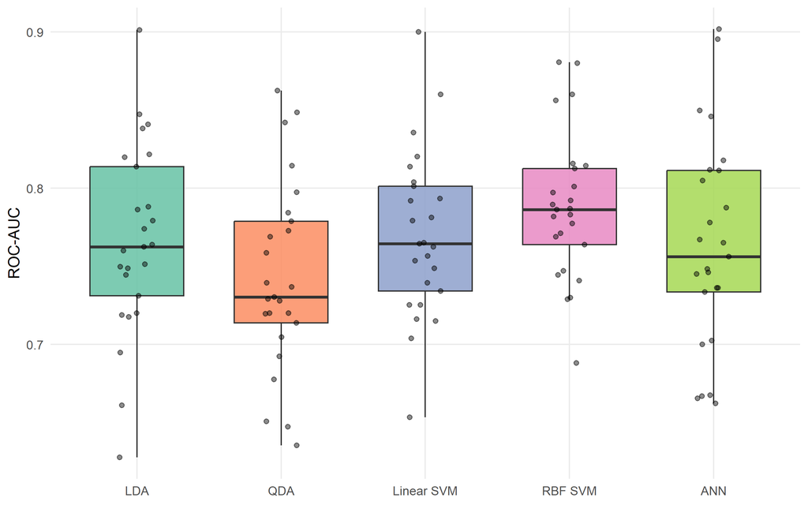

ROC-AUC distributions across the 25 validation resamples.

```r
auc_resamples <- bind_rows(
  fit_lda$resample |> transmute(Model = "LDA", Resample, ROC),
  fit_qda$resample |> transmute(Model = "QDA", Resample, ROC),
  fit_svm_linear$resample |> transmute(Model = "Linear SVM", Resample, ROC),
  fit_svm_rbf$resample |> transmute(Model = "RBF SVM", Resample, ROC),
  fit_ann$resample |> transmute(Model = "ANN", Resample, ROC)
) |>
  mutate(
    Model = factor(
      Model,
      levels = c("LDA", "QDA", "Linear SVM", "RBF SVM", "ANN")
    )
  )

auc_plot <- ggplot(auc_resamples, aes(Model, ROC, fill = Model)) +
  geom_boxplot(width = 0.65, outlier.shape = NA, alpha = 0.85) +
  geom_jitter(width = 0.12, alpha = 0.45, size = 1.4) +
  scale_fill_brewer(palette = "Set2", guide = "none") +
  labs(x = NULL, y = "ROC-AUC") +
  theme_minimal(base_size = 11) +
  theme(panel.grid.minor = element_blank())

ggsave(
  file.path(FIGURE_PATH, "model_auc_resamples.png"),
  auc_plot,
  width = 8,
  height = 5,
  dpi = 180
)

auc_plot
```

RBF SVM has the highest mean ROC-AUC. ANN has the highest sensitivity and balanced accuracy. LDA and linear SVM have high specificity but low sensitivity for deaths. Model preference depends on the evaluation objective and the relative cost of false negatives and false positives. Accuracy or training error alone is not sufficient for selection.

# 8 8. Exploratory threshold analysis

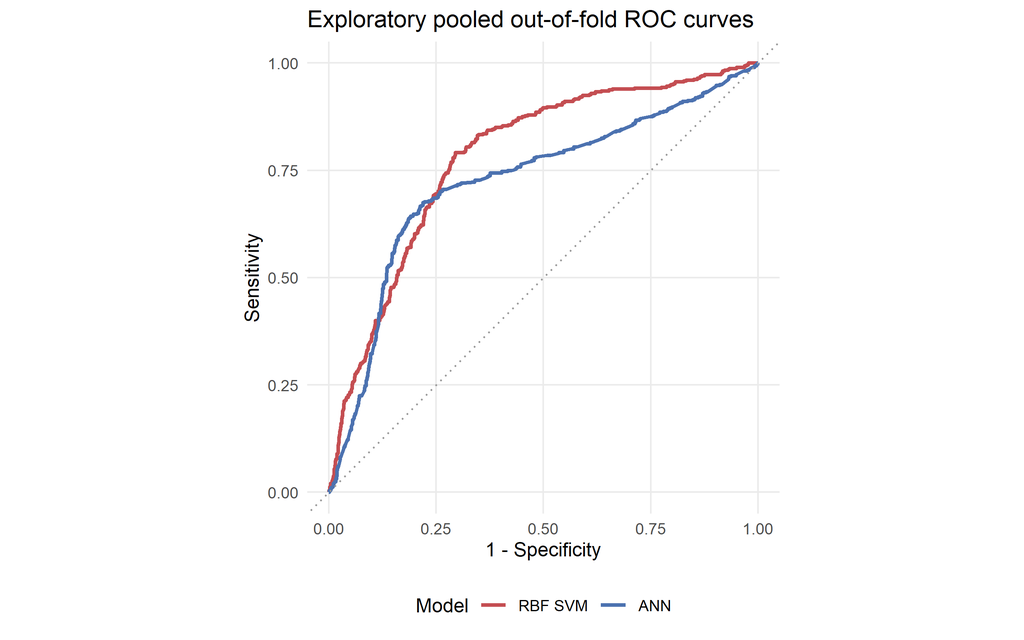

```r
rbf_pred <- fit_svm_rbf$pred |>
  filter(
    C == fit_svm_rbf$bestTune$C,
    sigma == fit_svm_rbf$bestTune$sigma
  )

ann_pred <- fit_ann$pred |>
  filter(
    size == fit_ann$bestTune$size,
    decay == fit_ann$bestTune$decay
  )

roc_rbf <- roc(
  response = rbf_pred$obs,
  predictor = rbf_pred$Died,
  levels = c("Survived", "Died"),
  direction = "<"
)

roc_ann <- roc(
  response = ann_pred$obs,
  predictor = ann_pred$Died,
  levels = c("Survived", "Died"),
  direction = "<"
)

roc_plot <- pROC::ggroc(
  list("RBF SVM" = roc_rbf, ANN = roc_ann),
  legacy.axes = TRUE,
  linewidth = 1
) +
  geom_abline(intercept = 0, slope = 1, linetype = 3, color = "grey60") +
  scale_color_manual(values = c("RBF SVM" = "#C44E52", ANN = "#4C72B0")) +
  coord_equal() +
  labs(
    x = "1 - Specificity",
    y = "Sensitivity",
    color = "Model",
    title = "Exploratory pooled out-of-fold ROC curves"
  ) +
  theme_minimal(base_size = 11) +
  theme(legend.position = "bottom", panel.grid.minor = element_blank())

ggsave(
  file.path(FIGURE_PATH, "roc_rbf_vs_ann.png"),
  roc_plot,
  width = 7,
  height = 6,
  dpi = 180
)

roc_plot
```

```r
coords_rbf <- coords(
  roc_rbf, x = "best", best.method = "youden",
  ret = c("threshold", "sensitivity", "specificity")
)

coords_ann <- coords(
  roc_ann, x = "best", best.method = "youden",
  ret = c("threshold", "sensitivity", "specificity")
)

threshold_comparison <- tibble(
  Model = c("RBF SVM", "ANN"),
  Pooled_OOF_AUC = c(as.numeric(auc(roc_rbf)), as.numeric(auc(roc_ann))),
  Threshold = c(
    as.numeric(coords_rbf$threshold),
    as.numeric(coords_ann$threshold)
  ),
  Sensitivity = c(
    as.numeric(coords_rbf$sensitivity),
    as.numeric(coords_ann$sensitivity)
  ),
  Specificity = c(
    as.numeric(coords_rbf$specificity),
    as.numeric(coords_ann$specificity)
  )
)

knitr::kable(threshold_comparison, digits = 3)
```

| Model | Pooled_OOF_AUC | Threshold | Sensitivity | Specificity |
| --- | --- | --- | --- | --- |
| RBF SVM | 0.782 | 0.323 | 0.792 | 0.705 |
| ANN | 0.725 | 0.215 | 0.675 | 0.781 |

Each patient appears once per repeat in the pooled out-of-fold predictions. Therefore, these pooled ROC curves and Youden thresholds are exploratory summaries of repeated predictions, not independent validation results and not clinical thresholds. The primary comparison remains the mean of 25 resample-level metrics.

# 9 9. What changed

| Item | Original coursework | Validation update |
| --- | --- | --- |
| SVM evaluation | Training-set prediction | Repeated cross-validation |
| Model comparison | Different validation schemes | Identical resampling folds |
| Preprocessing | ANN scaled before splitting | Estimated inside training folds |
| QDA priors | Reversed relative to factor order | Empirical priors in common workflow |
| Metrics | Mainly misclassification rate | AUC, sensitivity, specificity, balanced accuracy, accuracy |
| Conclusion | RBF SVM appeared dominant | Model choice depends on the objective |

# 10 10. Interpretation

The original 2.68% RBF SVM error does not estimate performance on unseen data. Under a common repeated cross-validation design, the performance gap is smaller and the models show different error profiles. RBF SVM provides the strongest average rank discrimination in this run. ANN identifies a larger share of deaths and has the highest balanced accuracy. LDA and linear SVM favor correct classification of survivors at the cost of lower death sensitivity.

This is classification of DEATH_EVENT, not formal survival analysis, independent risk-factor inference, or evidence of clinical utility.

# 11 11. Limitations

- The sample contains 299 patients and 96 deaths.
- The dataset is observational.
- No external validation dataset is used.
- Hyperparameter selection and performance estimation are not separated by nested cross-validation, so modest optimistic bias may remain.
- The pooled repeated-CV threshold analysis is exploratory.
- The analysis classifies DEATH_EVENT. It is not survival analysis and does not estimate mortality at a fixed time horizon.
- Six continuous variables were retained for the coursework comparison.
- The ANN implementation changed from neuralnet to nnet to support common resampling.